# Risk Factor Analysis

## Outcome Variable

**Outcome Variable:** ever_stunted

## Predictor Variables

**Intervention Variable:** tr

**Adjustment Set:**

unadjusted

## Stratifying Variables

The analysis was stratified on these variable(s):

- agecat
- studyid
- country
- intXparity

## Data Summary

| agecat | studyid | country | intXparity | ever_stunted | n_cell | n |
| --- | --- | --- | --- | --- | --- | --- |
| 0-6 months | iLiNS_DYADM_LNS | MALAWI | 1_0-6 months | 0 | 5 | 9 |
| 0-6 months | iLiNS_DYADM_LNS | MALAWI | 1_0-6 months | 1 | 4 | 9 |
| 0-6 months | iLiNS_DYADM_LNS | MALAWI | 2_0-6 months | 0 | 6 | 8 |
| 0-6 months | iLiNS_DYADM_LNS | MALAWI | 2_0-6 months | 1 | 2 | 8 |
| 0-6 months | iLiNS_DYADM_LNS | MALAWI | 3+_0-6 months | 0 | 22 | 26 |
| 0-6 months | iLiNS_DYADM_LNS | MALAWI | 3+_0-6 months | 1 | 4 | 26 |
| 0-6 months | ki1000110-WASH-Bangladesh | BANGLADESH | 1_0-6 months | 0 | 67 | 78 |
| 0-6 months | ki1000110-WASH-Bangladesh | BANGLADESH | 1_0-6 months | 1 | 11 | 78 |
| 0-6 months | ki1000110-WASH-Bangladesh | BANGLADESH | 2_0-6 months | 0 | 64 | 70 |
| 0-6 months | ki1000110-WASH-Bangladesh | BANGLADESH | 2_0-6 months | 1 | 6 | 70 |
| 0-6 months | ki1000110-WASH-Bangladesh | BANGLADESH | 3+_0-6 months | 0 | 69 | 73 |
| 0-6 months | ki1000110-WASH-Bangladesh | BANGLADESH | 3+_0-6 months | 1 | 4 | 73 |
| 0-6 months | ki1000304b-SAS-CompFeed | INDIA | 1_0-6 months | 0 | 165 | 231 |
| 0-6 months | ki1000304b-SAS-CompFeed | INDIA | 1_0-6 months | 1 | 66 | 231 |
| 0-6 months | ki1000304b-SAS-CompFeed | INDIA | 2_0-6 months | 0 | 143 | 193 |
| 0-6 months | ki1000304b-SAS-CompFeed | INDIA | 2_0-6 months | 1 | 50 | 193 |
| 0-6 months | ki1000304b-SAS-CompFeed | INDIA | 3+_0-6 months | 0 | 261 | 368 |
| 0-6 months | ki1000304b-SAS-CompFeed | INDIA | 3+_0-6 months | 1 | 107 | 368 |
| 0-6 months | ki1000304b-SAS-FoodSuppl | INDIA | 1_0-6 months | 0 | 46 | 77 |
| 0-6 months | ki1000304b-SAS-FoodSuppl | INDIA | 1_0-6 months | 1 | 31 | 77 |
| 0-6 months | ki1000304b-SAS-FoodSuppl | INDIA | 2_0-6 months | 0 | 58 | 91 |
| 0-6 months | ki1000304b-SAS-FoodSuppl | INDIA | 2_0-6 months | 1 | 33 | 91 |
| 0-6 months | ki1000304b-SAS-FoodSuppl | INDIA | 3+_0-6 months | 0 | 139 | 228 |
| 0-6 months | ki1000304b-SAS-FoodSuppl | INDIA | 3+_0-6 months | 1 | 89 | 228 |
| 0-6 months | ki1017093b-PROVIDE | BANGLADESH | 1_0-6 months | 0 | 199 | 241 |
| 0-6 months | ki1017093b-PROVIDE | BANGLADESH | 1_0-6 months | 1 | 42 | 241 |
| 0-6 months | ki1017093b-PROVIDE | BANGLADESH | 2_0-6 months | 0 | 198 | 227 |
| 0-6 months | ki1017093b-PROVIDE | BANGLADESH | 2_0-6 months | 1 | 29 | 227 |
| 0-6 months | ki1017093b-PROVIDE | BANGLADESH | 3+_0-6 months | 0 | 154 | 172 |
| 0-6 months | ki1017093b-PROVIDE | BANGLADESH | 3+_0-6 months | 1 | 18 | 172 |

[output cut: 102 more lines]

The following strata were considered:

- agecat: 0-6 months, studyid: iLiNS_DYADM_LNS, country: MALAWI, intXparity: 1_0-6 months
- agecat: 0-6 months, studyid: iLiNS_DYADM_LNS, country: MALAWI, intXparity: 2_0-6 months
- agecat: 0-6 months, studyid: iLiNS_DYADM_LNS, country: MALAWI, intXparity: 3+_0-6 months
- agecat: 0-6 months, studyid: ki1000110-WASH-Bangladesh, country: BANGLADESH, intXparity: 1_0-6 months
- agecat: 0-6 months, studyid: ki1000110-WASH-Bangladesh, country: BANGLADESH, intXparity: 2_0-6 months
- agecat: 0-6 months, studyid: ki1000110-WASH-Bangladesh, country: BANGLADESH, intXparity: 3+_0-6 months
- agecat: 0-6 months, studyid: ki1000304b-SAS-CompFeed, country: INDIA, intXparity: 1_0-6 months
- agecat: 0-6 months, studyid: ki1000304b-SAS-CompFeed, country: INDIA, intXparity: 2_0-6 months
- agecat: 0-6 months, studyid: ki1000304b-SAS-CompFeed, country: INDIA, intXparity: 3+_0-6 months
- agecat: 0-6 months, studyid: ki1000304b-SAS-FoodSuppl, country: INDIA, intXparity: 1_0-6 months
- agecat: 0-6 months, studyid: ki1000304b-SAS-FoodSuppl, country: INDIA, intXparity: 2_0-6 months
- agecat: 0-6 months, studyid: ki1000304b-SAS-FoodSuppl, country: INDIA, intXparity: 3+_0-6 months
- agecat: 0-6 months, studyid: ki1017093b-PROVIDE, country: BANGLADESH, intXparity: 1_0-6 months
- agecat: 0-6 months, studyid: ki1017093b-PROVIDE, country: BANGLADESH, intXparity: 2_0-6 months
- agecat: 0-6 months, studyid: ki1017093b-PROVIDE, country: BANGLADESH, intXparity: 3+_0-6 months
- agecat: 0-6 months, studyid: ki1066203-TanzaniaChild2, country: TANZANIA, UNITED REPUBLIC OF, intXparity: 1_0-6 months
- agecat: 0-6 months, studyid: ki1066203-TanzaniaChild2, country: TANZANIA, UNITED REPUBLIC OF, intXparity: 2_0-6 months
- agecat: 0-6 months, studyid: ki1066203-TanzaniaChild2, country: TANZANIA, UNITED REPUBLIC OF, intXparity: 3+_0-6 months
- agecat: 0-6 months, studyid: ki1112895-Burkina Faso Zn, country: BURKINA FASO, intXparity: 1_0-6 months
- agecat: 0-6 months, studyid: ki1112895-Burkina Faso Zn, country: BURKINA FASO, intXparity: 2_0-6 months
- agecat: 0-6 months, studyid: ki1112895-Burkina Faso Zn, country: BURKINA FASO, intXparity: 3+_0-6 months
- agecat: 0-6 months, studyid: ki1126311-ZVITAMBO, country: ZIMBABWE, intXparity: 1_0-6 months
- agecat: 0-6 months, studyid: ki1126311-ZVITAMBO, country: ZIMBABWE, intXparity: 2_0-6 months
- agecat: 0-6 months, studyid: ki1126311-ZVITAMBO, country: ZIMBABWE, intXparity: 3+_0-6 months
- agecat: 0-6 months, studyid: ki1135781-COHORTS, country: GUATEMALA, intXparity: 1_0-6 months
- agecat: 0-6 months, studyid: ki1135781-COHORTS, country: GUATEMALA, intXparity: 2_0-6 months
- agecat: 0-6 months, studyid: ki1135781-COHORTS, country: GUATEMALA, intXparity: 3+_0-6 months
- agecat: 0-6 months, studyid: ki1148112-iLiNS-DYAD-M, country: MALAWI, intXparity: 1_0-6 months
- agecat: 0-6 months, studyid: ki1148112-iLiNS-DYAD-M, country: MALAWI, intXparity: 2_0-6 months
- agecat: 0-6 months, studyid: ki1148112-iLiNS-DYAD-M, country: MALAWI, intXparity: 3+_0-6 months
- agecat: 0-6 months, studyid: kiGH5241-JiVitA-3, country: BANGLADESH, intXparity: 1_0-6 months
- agecat: 0-6 months, studyid: kiGH5241-JiVitA-3, country: BANGLADESH, intXparity: 2_0-6 months
- agecat: 0-6 months, studyid: kiGH5241-JiVitA-3, country: BANGLADESH, intXparity: 3+_0-6 months
- agecat: 6-24 months, studyid: iLiNS_DYADM_LNS, country: MALAWI, intXparity: 1_6-24 months
- agecat: 6-24 months, studyid: iLiNS_DYADM_LNS, country: MALAWI, intXparity: 2_6-24 months
- agecat: 6-24 months, studyid: iLiNS_DYADM_LNS, country: MALAWI, intXparity: 3+_6-24 months
- agecat: 6-24 months, studyid: ki1000110-WASH-Bangladesh, country: BANGLADESH, intXparity: 1_6-24 months
- agecat: 6-24 months, studyid: ki1000110-WASH-Bangladesh, country: BANGLADESH, intXparity: 2_6-24 months
- agecat: 6-24 months, studyid: ki1000110-WASH-Bangladesh, country: BANGLADESH, intXparity: 3+_6-24 months
- agecat: 6-24 months, studyid: ki1000304b-SAS-CompFeed, country: INDIA, intXparity: 1_6-24 months
- agecat: 6-24 months, studyid: ki1000304b-SAS-CompFeed, country: INDIA, intXparity: 2_6-24 months
- agecat: 6-24 months, studyid: ki1000304b-SAS-CompFeed, country: INDIA, intXparity: 3+_6-24 months
- agecat: 6-24 months, studyid: ki1000304b-SAS-FoodSuppl, country: INDIA, intXparity: 1_6-24 months
- agecat: 6-24 months, studyid: ki1000304b-SAS-FoodSuppl, country: INDIA, intXparity: 2_6-24 months
- agecat: 6-24 months, studyid: ki1000304b-SAS-FoodSuppl, country: INDIA, intXparity: 3+_6-24 months
- agecat: 6-24 months, studyid: ki1017093b-PROVIDE, country: BANGLADESH, intXparity: 1_6-24 months
- agecat: 6-24 months, studyid: ki1017093b-PROVIDE, country: BANGLADESH, intXparity: 2_6-24 months
- agecat: 6-24 months, studyid: ki1017093b-PROVIDE, country: BANGLADESH, intXparity: 3+_6-24 months
- agecat: 6-24 months, studyid: ki1066203-TanzaniaChild2, country: TANZANIA, UNITED REPUBLIC OF, intXparity: 1_6-24 months
- agecat: 6-24 months, studyid: ki1066203-TanzaniaChild2, country: TANZANIA, UNITED REPUBLIC OF, intXparity: 2_6-24 months
- agecat: 6-24 months, studyid: ki1066203-TanzaniaChild2, country: TANZANIA, UNITED REPUBLIC OF, intXparity: 3+_6-24 months
- agecat: 6-24 months, studyid: ki1112895-Burkina Faso Zn, country: BURKINA FASO, intXparity: 1_6-24 months
- agecat: 6-24 months, studyid: ki1112895-Burkina Faso Zn, country: BURKINA FASO, intXparity: 2_6-24 months
- agecat: 6-24 months, studyid: ki1112895-Burkina Faso Zn, country: BURKINA FASO, intXparity: 3+_6-24 months
- agecat: 6-24 months, studyid: ki1126311-ZVITAMBO, country: ZIMBABWE, intXparity: 1_6-24 months
- agecat: 6-24 months, studyid: ki1126311-ZVITAMBO, country: ZIMBABWE, intXparity: 2_6-24 months
- agecat: 6-24 months, studyid: ki1126311-ZVITAMBO, country: ZIMBABWE, intXparity: 3+_6-24 months
- agecat: 6-24 months, studyid: ki1135781-COHORTS, country: GUATEMALA, intXparity: 1_6-24 months
- agecat: 6-24 months, studyid: ki1135781-COHORTS, country: GUATEMALA, intXparity: 2_6-24 months
- agecat: 6-24 months, studyid: ki1135781-COHORTS, country: GUATEMALA, intXparity: 3+_6-24 months
- agecat: 6-24 months, studyid: ki1148112-iLiNS-DYAD-M, country: MALAWI, intXparity: 1_6-24 months
- agecat: 6-24 months, studyid: ki1148112-iLiNS-DYAD-M, country: MALAWI, intXparity: 2_6-24 months
- agecat: 6-24 months, studyid: ki1148112-iLiNS-DYAD-M, country: MALAWI, intXparity: 3+_6-24 months
- agecat: 6-24 months, studyid: kiGH5241-JiVitA-3, country: BANGLADESH, intXparity: 1_6-24 months
- agecat: 6-24 months, studyid: kiGH5241-JiVitA-3, country: BANGLADESH, intXparity: 2_6-24 months
- agecat: 6-24 months, studyid: kiGH5241-JiVitA-3, country: BANGLADESH, intXparity: 3+_6-24 months

### Dropped Strata

Some strata were dropped due to rare outcomes:

- agecat: 0-6 months, studyid: iLiNS_DYADM_LNS, country: MALAWI, intXparity: 1_0-6 months
- agecat: 0-6 months, studyid: iLiNS_DYADM_LNS, country: MALAWI, intXparity: 2_0-6 months
- agecat: 0-6 months, studyid: iLiNS_DYADM_LNS, country: MALAWI, intXparity: 3+_0-6 months
- agecat: 0-6 months, studyid: ki1000110-WASH-Bangladesh, country: BANGLADESH, intXparity: 3+_0-6 months
- agecat: 0-6 months, studyid: ki1112895-Burkina Faso Zn, country: BURKINA FASO, intXparity: 1_0-6 months
- agecat: 0-6 months, studyid: ki1112895-Burkina Faso Zn, country: BURKINA FASO, intXparity: 2_0-6 months
- agecat: 0-6 months, studyid: ki1112895-Burkina Faso Zn, country: BURKINA FASO, intXparity: 3+_0-6 months
- agecat: 0-6 months, studyid: ki1148112-iLiNS-DYAD-M, country: MALAWI, intXparity: 2_0-6 months

## Methods Detail

We’re interested in the causal parameters $E[Y_a]$ for all values of $a \in \mathcal{A}$. These parameters represent the mean outcome if, possibly contrary to fact, we intervened to set all units to have $A=a$. Under the randomization and positivity assumptions, these are identified by the statistical parameters $\psi_a=E_W[E_{Y|A,W}(Y|A=a,W)]$. In addition, we’re interested in the mean of $Y$, $E[Y]$ under no intervention (the observed mean). We will estimate these parameters by using SuperLearner to fit the relevant likelihood factors – $E_{Y|A,W}(Y|A=a,W)$ and $p(A=a|W)$, and then updating our likelihood fit using a joint TMLE.

For unadjusted analyses ($W=\{\}$), initial likelihoods were estimated using Lrnr_glm to estimate the simple $E(Y|A)$ and Lrnr_mean to estimate $p(A)$. For adjusted analyses, a small library containing Lrnr_glmnet, Lrnr_xgboost, and Lrnr_mean was used.

Having estimated these parameters, we will then use the delta method to estimate relative risks and attributable risks relative to a prespecified baseline level of $A$.

```
##           ever_stunted
## tr           0   1
##   Control    0   0
##   LNS        0   0
##   Maternal   0   0
##   Other      0   0
##   VitA       0   0
##   Zinc     776 450
##           ever_stunted
## tr           0   1
##   Control    0   0
##   LNS        0   0
##   Maternal   0   0
##   Other      0   0
##   VitA       0   0
##   Zinc     725 379
##           ever_stunted
## tr            0    1
##   Control     0    0
##   LNS         0    0
##   Maternal    0    0
##   Other       0    0
##   VitA        0    0
##   Zinc     2244 1210
```

# Results Detail

## Results Plots

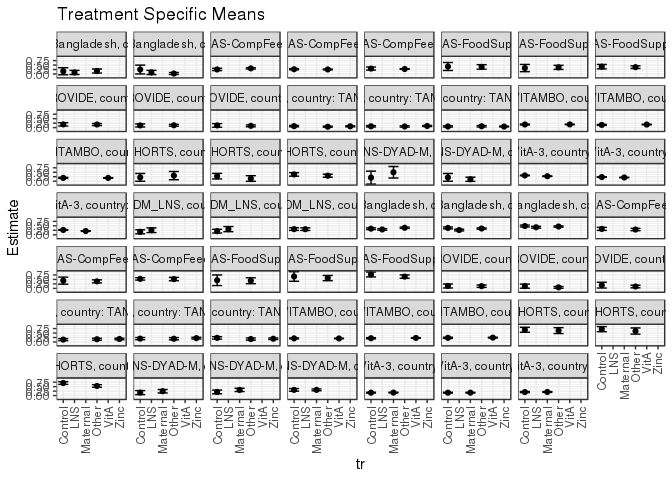

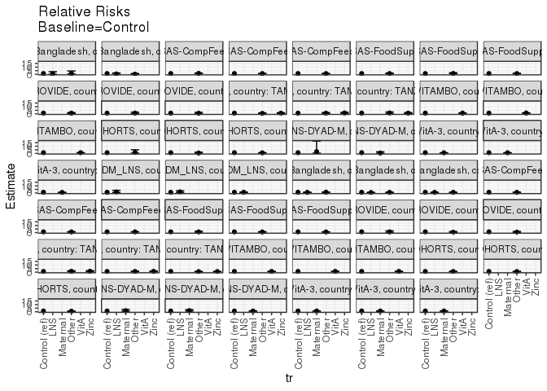

[figure not shown]

[figure not shown]

## Results Table

### Parameter: TSM

| agecat | studyid | country | intXparity | intervention_level | baseline_level | estimate | ci_lower | ci_upper |
| --- | --- | --- | --- | --- | --- | --- | --- | --- |
| 0-6 months | ki1000110-WASH-Bangladesh | BANGLADESH | 1_0-6 months | Control | NA | 0.1538462 | -0.0435535 | 0.3512458 |
| 0-6 months | ki1000110-WASH-Bangladesh | BANGLADESH | 1_0-6 months | LNS | NA | 0.0869565 | -0.0289433 | 0.2028564 |
| 0-6 months | ki1000110-WASH-Bangladesh | BANGLADESH | 1_0-6 months | Other | NA | 0.1666667 | 0.0532285 | 0.2801048 |
| 0-6 months | ki1000110-WASH-Bangladesh | BANGLADESH | 2_0-6 months | Control | NA | 0.2500000 | 0.0032356 | 0.4967644 |
| 0-6 months | ki1000110-WASH-Bangladesh | BANGLADESH | 2_0-6 months | LNS | NA | 0.0869565 | -0.0290294 | 0.2029425 |
| 0-6 months | ki1000110-WASH-Bangladesh | BANGLADESH | 2_0-6 months | Other | NA | 0.0285714 | -0.0270203 | 0.0841631 |
| 0-6 months | ki1000304b-SAS-CompFeed | INDIA | 1_0-6 months | Control | NA | 0.2545455 | 0.1917175 | 0.3173734 |
| 0-6 months | ki1000304b-SAS-CompFeed | INDIA | 1_0-6 months | Other | NA | 0.3140496 | 0.2782617 | 0.3498375 |
| 0-6 months | ki1000304b-SAS-CompFeed | INDIA | 2_0-6 months | Control | NA | 0.2658228 | 0.2327756 | 0.2988699 |
| 0-6 months | ki1000304b-SAS-CompFeed | INDIA | 2_0-6 months | Other | NA | 0.2543860 | 0.2300902 | 0.2786817 |
| 0-6 months | ki1000304b-SAS-CompFeed | INDIA | 3+_0-6 months | Control | NA | 0.3033708 | 0.2178378 | 0.3889037 |
| 0-6 months | ki1000304b-SAS-CompFeed | INDIA | 3+_0-6 months | Other | NA | 0.2789474 | 0.2602320 | 0.2976627 |
| 0-6 months | ki1000304b-SAS-FoodSuppl | INDIA | 1_0-6 months | Control | NA | 0.4210526 | 0.1975938 | 0.6445115 |
| 0-6 months | ki1000304b-SAS-FoodSuppl | INDIA | 1_0-6 months | Other | NA | 0.3965517 | 0.2698325 | 0.5232710 |
| 0-6 months | ki1000304b-SAS-FoodSuppl | INDIA | 2_0-6 months | Control | NA | 0.3333333 | 0.1305970 | 0.5360697 |
| 0-6 months | ki1000304b-SAS-FoodSuppl | INDIA | 2_0-6 months | Other | NA | 0.3714286 | 0.2576099 | 0.4852472 |
| 0-6 months | ki1000304b-SAS-FoodSuppl | INDIA | 3+_0-6 months | Control | NA | 0.4098361 | 0.2861476 | 0.5335245 |
| 0-6 months | ki1000304b-SAS-FoodSuppl | INDIA | 3+_0-6 months | Other | NA | 0.3832335 | 0.3093349 | 0.4571322 |
| 0-6 months | ki1017093b-PROVIDE | BANGLADESH | 1_0-6 months | Control | NA | 0.1791045 | 0.0870996 | 0.2711093 |
| 0-6 months | ki1017093b-PROVIDE | BANGLADESH | 1_0-6 months | Other | NA | 0.1724138 | 0.1161707 | 0.2286569 |
| 0-6 months | ki1017093b-PROVIDE | BANGLADESH | 2_0-6 months | Control | NA | 0.1206897 | 0.0366665 | 0.2047128 |
| 0-6 months | ki1017093b-PROVIDE | BANGLADESH | 2_0-6 months | Other | NA | 0.1301775 | 0.0793327 | 0.1810223 |
| 0-6 months | ki1017093b-PROVIDE | BANGLADESH | 3+_0-6 months | Control | NA | 0.1219512 | 0.0214955 | 0.2224070 |
| 0-6 months | ki1017093b-PROVIDE | BANGLADESH | 3+_0-6 months | Other | NA | 0.0992366 | 0.0478891 | 0.1505842 |
| 0-6 months | ki1066203-TanzaniaChild2 | TANZANIA, UNITED REPUBLIC OF | 1_0-6 months | Control | NA | 0.0819672 | 0.0421966 | 0.1217378 |
| 0-6 months | ki1066203-TanzaniaChild2 | TANZANIA, UNITED REPUBLIC OF | 1_0-6 months | Other | NA | 0.0492611 | 0.0194709 | 0.0790513 |
| 0-6 months | ki1066203-TanzaniaChild2 | TANZANIA, UNITED REPUBLIC OF | 1_0-6 months | Zinc | NA | 0.0718232 | 0.0452079 | 0.0984385 |
| 0-6 months | ki1066203-TanzaniaChild2 | TANZANIA, UNITED REPUBLIC OF | 2_0-6 months | Control | NA | 0.0740741 | 0.0367115 | 0.1114367 |
| 0-6 months | ki1066203-TanzaniaChild2 | TANZANIA, UNITED REPUBLIC OF | 2_0-6 months | Other | NA | 0.0635838 | 0.0271981 | 0.0999696 |
| 0-6 months | ki1066203-TanzaniaChild2 | TANZANIA, UNITED REPUBLIC OF | 2_0-6 months | Zinc | NA | 0.0901639 | 0.0608007 | 0.1195272 |

[output cut: 91 more lines]

### Parameter: E(Y)

| agecat | studyid | country | intXparity | intervention_level | baseline_level | estimate | ci_lower | ci_upper |
| --- | --- | --- | --- | --- | --- | --- | --- | --- |
| 0-6 months | ki1000110-WASH-Bangladesh | BANGLADESH | 1_0-6 months | NA | NA | 0.1410256 | 0.0632861 | 0.2187652 |
| 0-6 months | ki1000110-WASH-Bangladesh | BANGLADESH | 2_0-6 months | NA | NA | 0.0857143 | 0.0196615 | 0.1517671 |
| 0-6 months | ki1000304b-SAS-CompFeed | INDIA | 1_0-6 months | NA | NA | 0.2857143 | 0.2414443 | 0.3299843 |
| 0-6 months | ki1000304b-SAS-CompFeed | INDIA | 2_0-6 months | NA | NA | 0.2590674 | 0.2388727 | 0.2792620 |
| 0-6 months | ki1000304b-SAS-CompFeed | INDIA | 3+_0-6 months | NA | NA | 0.2907609 | 0.2479343 | 0.3335874 |
| 0-6 months | ki1000304b-SAS-FoodSuppl | INDIA | 1_0-6 months | NA | NA | 0.4025974 | 0.2923393 | 0.5128555 |
| 0-6 months | ki1000304b-SAS-FoodSuppl | INDIA | 2_0-6 months | NA | NA | 0.3626374 | 0.2633129 | 0.4619619 |
| 0-6 months | ki1000304b-SAS-FoodSuppl | INDIA | 3+_0-6 months | NA | NA | 0.3903509 | 0.3268905 | 0.4538113 |
| 0-6 months | ki1017093b-PROVIDE | BANGLADESH | 1_0-6 months | NA | NA | 0.1742739 | 0.1262810 | 0.2222667 |
| 0-6 months | ki1017093b-PROVIDE | BANGLADESH | 2_0-6 months | NA | NA | 0.1277533 | 0.0842322 | 0.1712744 |
| 0-6 months | ki1017093b-PROVIDE | BANGLADESH | 3+_0-6 months | NA | NA | 0.1046512 | 0.0587717 | 0.1505306 |
| 0-6 months | ki1066203-TanzaniaChild2 | TANZANIA, UNITED REPUBLIC OF | 1_0-6 months | NA | NA | 0.0681818 | 0.0501064 | 0.0862572 |
| 0-6 months | ki1066203-TanzaniaChild2 | TANZANIA, UNITED REPUBLIC OF | 2_0-6 months | NA | NA | 0.0796703 | 0.0599869 | 0.0993538 |
| 0-6 months | ki1066203-TanzaniaChild2 | TANZANIA, UNITED REPUBLIC OF | 3+_0-6 months | NA | NA | 0.0637119 | 0.0458842 | 0.0815396 |
| 0-6 months | ki1126311-ZVITAMBO | ZIMBABWE | 1_0-6 months | NA | NA | 0.1768210 | 0.1645146 | 0.1891274 |
| 0-6 months | ki1126311-ZVITAMBO | ZIMBABWE | 2_0-6 months | NA | NA | 0.1657122 | 0.1519228 | 0.1795017 |
| 0-6 months | ki1126311-ZVITAMBO | ZIMBABWE | 3+_0-6 months | NA | NA | 0.1832441 | 0.1684107 | 0.1980774 |
| 0-6 months | ki1135781-COHORTS | GUATEMALA | 1_0-6 months | NA | NA | 0.2666667 | 0.1057192 | 0.4276141 |
| 0-6 months | ki1135781-COHORTS | GUATEMALA | 2_0-6 months | NA | NA | 0.2307692 | 0.1151366 | 0.3464018 |
| 0-6 months | ki1135781-COHORTS | GUATEMALA | 3+_0-6 months | NA | NA | 0.3379630 | 0.2747357 | 0.4011903 |
| 0-6 months | ki1148112-iLiNS-DYAD-M | MALAWI | 1_0-6 months | NA | NA | 0.4000000 | 0.1433805 | 0.6566195 |
| 0-6 months | ki1148112-iLiNS-DYAD-M | MALAWI | 3+_0-6 months | NA | NA | 0.1428571 | 0.0357462 | 0.2499681 |
| 0-6 months | kiGH5241-JiVitA-3 | BANGLADESH | 1_0-6 months | NA | NA | 0.3005464 | 0.2882407 | 0.3128522 |
| 0-6 months | kiGH5241-JiVitA-3 | BANGLADESH | 2_0-6 months | NA | NA | 0.2191569 | 0.2080052 | 0.2303085 |
| 0-6 months | kiGH5241-JiVitA-3 | BANGLADESH | 3+_0-6 months | NA | NA | 0.2398637 | 0.2258572 | 0.2538702 |
| 6-24 months | iLiNS_DYADM_LNS | MALAWI | 1_6-24 months | NA | NA | 0.2117647 | 0.1243945 | 0.2991349 |
| 6-24 months | iLiNS_DYADM_LNS | MALAWI | 2_6-24 months | NA | NA | 0.2500000 | 0.1639827 | 0.3360173 |
| 6-24 months | iLiNS_DYADM_LNS | MALAWI | 3+_6-24 months | NA | NA | 0.3159609 | 0.2638721 | 0.3680497 |
| 6-24 months | ki1000110-WASH-Bangladesh | BANGLADESH | 1_6-24 months | NA | NA | 0.3557568 | 0.3318850 | 0.3796286 |
| 6-24 months | ki1000110-WASH-Bangladesh | BANGLADESH | 2_6-24 months | NA | NA | 0.3391244 | 0.3146559 | 0.3635929 |
| 6-24 months | ki1000110-WASH-Bangladesh | BANGLADESH | 3+_6-24 months | NA | NA | 0.4583068 | 0.4336604 | 0.4829532 |
| 6-24 months | ki1000304b-SAS-CompFeed | INDIA | 1_6-24 months | NA | NA | 0.3117647 | 0.2569374 | 0.3665920 |
| 6-24 months | ki1000304b-SAS-CompFeed | INDIA | 2_6-24 months | NA | NA | 0.4085366 | 0.3120489 | 0.5050242 |
| 6-24 months | ki1000304b-SAS-CompFeed | INDIA | 3+_6-24 months | NA | NA | 0.5255973 | 0.4671777 | 0.5840168 |
| 6-24 months | ki1000304b-SAS-FoodSuppl | INDIA | 1_6-24 months | NA | NA | 0.4347826 | 0.2899436 | 0.5796217 |
| 6-24 months | ki1000304b-SAS-FoodSuppl | INDIA | 2_6-24 months | NA | NA | 0.5964912 | 0.4679973 | 0.7249852 |
| 6-24 months | ki1000304b-SAS-FoodSuppl | INDIA | 3+_6-24 months | NA | NA | 0.6911765 | 0.6132418 | 0.7691112 |
| 6-24 months | ki1017093b-PROVIDE | BANGLADESH | 1_6-24 months | NA | NA | 0.1268657 | 0.0703024 | 0.1834290 |
| 6-24 months | ki1017093b-PROVIDE | BANGLADESH | 2_6-24 months | NA | NA | 0.0756303 | 0.0279237 | 0.1233368 |
| 6-24 months | ki1017093b-PROVIDE | BANGLADESH | 3+_6-24 months | NA | NA | 0.1235955 | 0.0548316 | 0.1923594 |
| 6-24 months | ki1066203-TanzaniaChild2 | TANZANIA, UNITED REPUBLIC OF | 1_6-24 months | NA | NA | 0.1558219 | 0.1263814 | 0.1852624 |
| 6-24 months | ki1066203-TanzaniaChild2 | TANZANIA, UNITED REPUBLIC OF | 2_6-24 months | NA | NA | 0.1993300 | 0.1672571 | 0.2314029 |
| 6-24 months | ki1066203-TanzaniaChild2 | TANZANIA, UNITED REPUBLIC OF | 3+_6-24 months | NA | NA | 0.1899160 | 0.1583731 | 0.2214588 |
| 6-24 months | ki1126311-ZVITAMBO | ZIMBABWE | 1_6-24 months | NA | NA | 0.1983280 | 0.1850572 | 0.2115989 |
| 6-24 months | ki1126311-ZVITAMBO | ZIMBABWE | 2_6-24 months | NA | NA | 0.2216216 | 0.2056230 | 0.2376203 |
| 6-24 months | ki1126311-ZVITAMBO | ZIMBABWE | 3+_6-24 months | NA | NA | 0.2397785 | 0.2225056 | 0.2570515 |
| 6-24 months | ki1135781-COHORTS | GUATEMALA | 1_6-24 months | NA | NA | 0.6623377 | 0.5560159 | 0.7686595 |
| 6-24 months | ki1135781-COHORTS | GUATEMALA | 2_6-24 months | NA | NA | 0.6714286 | 0.5606034 | 0.7822537 |
| 6-24 months | ki1135781-COHORTS | GUATEMALA | 3+_6-24 months | NA | NA | 0.6085627 | 0.5555813 | 0.6615440 |
| 6-24 months | ki1148112-iLiNS-DYAD-M | MALAWI | 1_6-24 months | NA | NA | 0.2166667 | 0.1426475 | 0.2906858 |
| 6-24 months | ki1148112-iLiNS-DYAD-M | MALAWI | 2_6-24 months | NA | NA | 0.2750000 | 0.2052414 | 0.3447586 |
| 6-24 months | ki1148112-iLiNS-DYAD-M | MALAWI | 3+_6-24 months | NA | NA | 0.3186583 | 0.2767992 | 0.3605174 |
| 6-24 months | kiGH5241-JiVitA-3 | BANGLADESH | 1_6-24 months | NA | NA | 0.1638569 | 0.1485150 | 0.1791989 |
| 6-24 months | kiGH5241-JiVitA-3 | BANGLADESH | 2_6-24 months | NA | NA | 0.1621158 | 0.1463132 | 0.1779184 |
| 6-24 months | kiGH5241-JiVitA-3 | BANGLADESH | 3+_6-24 months | NA | NA | 0.1989258 | 0.1803335 | 0.2175181 |

### Parameter: RR

| agecat | studyid | country | intXparity | intervention_level | baseline_level | estimate | ci_lower | ci_upper |
| --- | --- | --- | --- | --- | --- | --- | --- | --- |
| 0-6 months | ki1000110-WASH-Bangladesh | BANGLADESH | 1_0-6 months | Control | Control | 1.0000000 | 1.0000000 | 1.0000000 |
| 0-6 months | ki1000110-WASH-Bangladesh | BANGLADESH | 1_0-6 months | LNS | Control | 0.5652174 | 0.0888654 | 3.5949958 |
| 0-6 months | ki1000110-WASH-Bangladesh | BANGLADESH | 1_0-6 months | Other | Control | 1.0833333 | 0.2534974 | 4.6296778 |
| 0-6 months | ki1000110-WASH-Bangladesh | BANGLADESH | 2_0-6 months | Control | Control | 1.0000000 | 1.0000000 | 1.0000000 |
| 0-6 months | ki1000110-WASH-Bangladesh | BANGLADESH | 2_0-6 months | LNS | Control | 0.3478261 | 0.0661790 | 1.8281182 |
| 0-6 months | ki1000110-WASH-Bangladesh | BANGLADESH | 2_0-6 months | Other | Control | 0.1142857 | 0.0128963 | 1.0127855 |
| 0-6 months | ki1000304b-SAS-CompFeed | INDIA | 1_0-6 months | Control | Control | 1.0000000 | 1.0000000 | 1.0000000 |
| 0-6 months | ki1000304b-SAS-CompFeed | INDIA | 1_0-6 months | Other | Control | 1.2337662 | 0.9410441 | 1.6175429 |
| 0-6 months | ki1000304b-SAS-CompFeed | INDIA | 2_0-6 months | Control | Control | 1.0000000 | 1.0000000 | 1.0000000 |
| 0-6 months | ki1000304b-SAS-CompFeed | INDIA | 2_0-6 months | Other | Control | 0.9569758 | 0.8178215 | 1.1198075 |
| 0-6 months | ki1000304b-SAS-CompFeed | INDIA | 3+_0-6 months | Control | Control | 1.0000000 | 1.0000000 | 1.0000000 |
| 0-6 months | ki1000304b-SAS-CompFeed | INDIA | 3+_0-6 months | Other | Control | 0.9194932 | 0.6881794 | 1.2285571 |
| 0-6 months | ki1000304b-SAS-FoodSuppl | INDIA | 1_0-6 months | Control | Control | 1.0000000 | 1.0000000 | 1.0000000 |
| 0-6 months | ki1000304b-SAS-FoodSuppl | INDIA | 1_0-6 months | Other | Control | 0.9418103 | 0.5068983 | 1.7498712 |
| 0-6 months | ki1000304b-SAS-FoodSuppl | INDIA | 2_0-6 months | Control | Control | 1.0000000 | 1.0000000 | 1.0000000 |
| 0-6 months | ki1000304b-SAS-FoodSuppl | INDIA | 2_0-6 months | Other | Control | 1.1142857 | 0.5639272 | 2.2017606 |
| 0-6 months | ki1000304b-SAS-FoodSuppl | INDIA | 3+_0-6 months | Control | Control | 1.0000000 | 1.0000000 | 1.0000000 |
| 0-6 months | ki1000304b-SAS-FoodSuppl | INDIA | 3+_0-6 months | Other | Control | 0.9350898 | 0.6536028 | 1.3378048 |
| 0-6 months | ki1017093b-PROVIDE | BANGLADESH | 1_0-6 months | Control | Control | 1.0000000 | 1.0000000 | 1.0000000 |
| 0-6 months | ki1017093b-PROVIDE | BANGLADESH | 1_0-6 months | Other | Control | 0.9626437 | 0.5238290 | 1.7690559 |
| 0-6 months | ki1017093b-PROVIDE | BANGLADESH | 2_0-6 months | Control | Control | 1.0000000 | 1.0000000 | 1.0000000 |
| 0-6 months | ki1017093b-PROVIDE | BANGLADESH | 2_0-6 months | Other | Control | 1.0786137 | 0.4854912 | 2.3963515 |
| 0-6 months | ki1017093b-PROVIDE | BANGLADESH | 3+_0-6 months | Control | Control | 1.0000000 | 1.0000000 | 1.0000000 |
| 0-6 months | ki1017093b-PROVIDE | BANGLADESH | 3+_0-6 months | Other | Control | 0.8137405 | 0.3076234 | 2.1525460 |
| 0-6 months | ki1066203-TanzaniaChild2 | TANZANIA, UNITED REPUBLIC OF | 1_0-6 months | Control | Control | 1.0000000 | 1.0000000 | 1.0000000 |
| 0-6 months | ki1066203-TanzaniaChild2 | TANZANIA, UNITED REPUBLIC OF | 1_0-6 months | Other | Control | 0.6009852 | 0.2767857 | 1.3049203 |
| 0-6 months | ki1066203-TanzaniaChild2 | TANZANIA, UNITED REPUBLIC OF | 1_0-6 months | Zinc | Control | 0.8762431 | 0.4758576 | 1.6135120 |
| 0-6 months | ki1066203-TanzaniaChild2 | TANZANIA, UNITED REPUBLIC OF | 2_0-6 months | Control | Control | 1.0000000 | 1.0000000 | 1.0000000 |
| 0-6 months | ki1066203-TanzaniaChild2 | TANZANIA, UNITED REPUBLIC OF | 2_0-6 months | Other | Control | 0.8583815 | 0.4003088 | 1.8406259 |
| 0-6 months | ki1066203-TanzaniaChild2 | TANZANIA, UNITED REPUBLIC OF | 2_0-6 months | Zinc | Control | 1.2172131 | 0.6677581 | 2.2187791 |

[output cut: 91 more lines]

### Parameter: PAR

| agecat | studyid | country | intXparity | intervention_level | baseline_level | estimate | ci_lower | ci_upper |
| --- | --- | --- | --- | --- | --- | --- | --- | --- |
| 0-6 months | ki1000110-WASH-Bangladesh | BANGLADESH | 1_0-6 months | Control | NA | -0.0128205 | -0.1917651 | 0.1661241 |
| 0-6 months | ki1000110-WASH-Bangladesh | BANGLADESH | 2_0-6 months | Control | NA | -0.1642857 | -0.3749470 | 0.0463755 |
| 0-6 months | ki1000304b-SAS-CompFeed | INDIA | 1_0-6 months | Control | NA | 0.0311688 | -0.0116378 | 0.0739754 |
| 0-6 months | ki1000304b-SAS-CompFeed | INDIA | 2_0-6 months | Control | NA | -0.0067554 | -0.0309778 | 0.0174669 |
| 0-6 months | ki1000304b-SAS-CompFeed | INDIA | 3+_0-6 months | Control | NA | -0.0126099 | -0.0592825 | 0.0340626 |
| 0-6 months | ki1000304b-SAS-FoodSuppl | INDIA | 1_0-6 months | Control | NA | -0.0184552 | -0.2119701 | 0.1750597 |
| 0-6 months | ki1000304b-SAS-FoodSuppl | INDIA | 2_0-6 months | Control | NA | 0.0293040 | -0.1495736 | 0.2081817 |
| 0-6 months | ki1000304b-SAS-FoodSuppl | INDIA | 3+_0-6 months | Control | NA | -0.0194852 | -0.1250306 | 0.0860602 |
| 0-6 months | ki1017093b-PROVIDE | BANGLADESH | 1_0-6 months | Control | NA | -0.0048306 | -0.0826868 | 0.0730256 |
| 0-6 months | ki1017093b-PROVIDE | BANGLADESH | 2_0-6 months | Control | NA | 0.0070636 | -0.0660546 | 0.0801819 |
| 0-6 months | ki1017093b-PROVIDE | BANGLADESH | 3+_0-6 months | Control | NA | -0.0173001 | -0.1032377 | 0.0686376 |
| 0-6 months | ki1066203-TanzaniaChild2 | TANZANIA, UNITED REPUBLIC OF | 1_0-6 months | Control | NA | -0.0137854 | -0.0474675 | 0.0198968 |
| 0-6 months | ki1066203-TanzaniaChild2 | TANZANIA, UNITED REPUBLIC OF | 2_0-6 months | Control | NA | 0.0055963 | -0.0269395 | 0.0381320 |
| 0-6 months | ki1066203-TanzaniaChild2 | TANZANIA, UNITED REPUBLIC OF | 3+_0-6 months | Control | NA | 0.0004935 | -0.0310666 | 0.0320536 |
| 0-6 months | ki1126311-ZVITAMBO | ZIMBABWE | 1_0-6 months | Control | NA | 0.0025291 | -0.0187865 | 0.0238446 |
| 0-6 months | ki1126311-ZVITAMBO | ZIMBABWE | 2_0-6 months | Control | NA | 0.0161521 | -0.0074478 | 0.0397520 |
| 0-6 months | ki1126311-ZVITAMBO | ZIMBABWE | 3+_0-6 months | Control | NA | -0.0004294 | -0.0253114 | 0.0244526 |
| 0-6 months | ki1135781-COHORTS | GUATEMALA | 1_0-6 months | Control | NA | 0.0523810 | -0.1181775 | 0.2229394 |
| 0-6 months | ki1135781-COHORTS | GUATEMALA | 2_0-6 months | Control | NA | -0.0504808 | -0.1380080 | 0.0370464 |
| 0-6 months | ki1135781-COHORTS | GUATEMALA | 3+_0-6 months | Control | NA | -0.0409844 | -0.1127377 | 0.0307688 |
| 0-6 months | ki1148112-iLiNS-DYAD-M | MALAWI | 1_0-6 months | Control | NA | 0.2000000 | -0.1312944 | 0.5312944 |
| 0-6 months | ki1148112-iLiNS-DYAD-M | MALAWI | 3+_0-6 months | Control | NA | -0.0714286 | -0.2364976 | 0.0936404 |
| 0-6 months | kiGH5241-JiVitA-3 | BANGLADESH | 1_0-6 months | Control | NA | -0.0217699 | -0.0342075 | -0.0093323 |
| 0-6 months | kiGH5241-JiVitA-3 | BANGLADESH | 2_0-6 months | Control | NA | -0.0114923 | -0.0227689 | -0.0002158 |
| 0-6 months | kiGH5241-JiVitA-3 | BANGLADESH | 3+_0-6 months | Control | NA | -0.0309315 | -0.0452881 | -0.0165750 |
| 6-24 months | iLiNS_DYADM_LNS | MALAWI | 1_6-24 months | Control | NA | 0.0450980 | -0.0431333 | 0.1333294 |
| 6-24 months | iLiNS_DYADM_LNS | MALAWI | 2_6-24 months | Control | NA | 0.0466102 | -0.0271583 | 0.1203787 |
| 6-24 months | iLiNS_DYADM_LNS | MALAWI | 3+_6-24 months | Control | NA | -0.0022209 | -0.0541397 | 0.0496979 |
| 6-24 months | ki1000110-WASH-Bangladesh | BANGLADESH | 1_6-24 months | Control | NA | 0.0135108 | -0.0284907 | 0.0555123 |
| 6-24 months | ki1000110-WASH-Bangladesh | BANGLADESH | 2_6-24 months | Control | NA | -0.0446291 | -0.0880073 | -0.0012509 |
| 6-24 months | ki1000110-WASH-Bangladesh | BANGLADESH | 3+_6-24 months | Control | NA | -0.0319979 | -0.0772250 | 0.0132292 |
| 6-24 months | ki1000304b-SAS-CompFeed | INDIA | 1_6-24 months | Control | NA | -0.0176471 | -0.0714744 | 0.0361803 |
| 6-24 months | ki1000304b-SAS-CompFeed | INDIA | 2_6-24 months | Control | NA | -0.0242992 | -0.1520244 | 0.1034259 |
| 6-24 months | ki1000304b-SAS-CompFeed | INDIA | 3+_6-24 months | Control | NA | -0.0058713 | -0.0662682 | 0.0545257 |
| 6-24 months | ki1000304b-SAS-FoodSuppl | INDIA | 1_6-24 months | Control | NA | -0.0197628 | -0.2789089 | 0.2393832 |
| 6-24 months | ki1000304b-SAS-FoodSuppl | INDIA | 2_6-24 months | Control | NA | -0.0701754 | -0.3119013 | 0.1715504 |
| 6-24 months | ki1000304b-SAS-FoodSuppl | INDIA | 3+_6-24 months | Control | NA | -0.0866013 | -0.2083275 | 0.0351249 |
| 6-24 months | ki1017093b-PROVIDE | BANGLADESH | 1_6-24 months | Control | NA | -0.0082695 | -0.1014010 | 0.0848621 |
| 6-24 months | ki1017093b-PROVIDE | BANGLADESH | 2_6-24 months | Control | NA | -0.0493697 | -0.1409985 | 0.0422590 |
| 6-24 months | ki1017093b-PROVIDE | BANGLADESH | 3+_6-24 months | Control | NA | -0.0582227 | -0.1924289 | 0.0759835 |
| 6-24 months | ki1066203-TanzaniaChild2 | TANZANIA, UNITED REPUBLIC OF | 1_6-24 months | Control | NA | 0.0220191 | -0.0277820 | 0.0718202 |
| 6-24 months | ki1066203-TanzaniaChild2 | TANZANIA, UNITED REPUBLIC OF | 2_6-24 months | Control | NA | 0.0110183 | -0.0426239 | 0.0646605 |
| 6-24 months | ki1066203-TanzaniaChild2 | TANZANIA, UNITED REPUBLIC OF | 3+_6-24 months | Control | NA | -0.0398138 | -0.0973195 | 0.0176919 |
| 6-24 months | ki1126311-ZVITAMBO | ZIMBABWE | 1_6-24 months | Control | NA | -0.0035281 | -0.0267096 | 0.0196534 |
| 6-24 months | ki1126311-ZVITAMBO | ZIMBABWE | 2_6-24 months | Control | NA | 0.0121728 | -0.0155159 | 0.0398615 |
| 6-24 months | ki1126311-ZVITAMBO | ZIMBABWE | 3+_6-24 months | Control | NA | 0.0082673 | -0.0202847 | 0.0368192 |
| 6-24 months | ki1135781-COHORTS | GUATEMALA | 1_6-24 months | Control | NA | -0.0194805 | -0.1120168 | 0.0730558 |
| 6-24 months | ki1135781-COHORTS | GUATEMALA | 2_6-24 months | Control | NA | -0.0465201 | -0.1463683 | 0.0533280 |
| 6-24 months | ki1135781-COHORTS | GUATEMALA | 3+_6-24 months | Control | NA | -0.0935650 | -0.1535113 | -0.0336187 |
| 6-24 months | ki1148112-iLiNS-DYAD-M | MALAWI | 1_6-24 months | Control | NA | 0.0500000 | -0.0465496 | 0.1465496 |
| 6-24 months | ki1148112-iLiNS-DYAD-M | MALAWI | 2_6-24 months | Control | NA | 0.0716102 | -0.0160717 | 0.1592921 |
| 6-24 months | ki1148112-iLiNS-DYAD-M | MALAWI | 3+_6-24 months | Control | NA | 0.0004765 | -0.0601329 | 0.0610859 |
| 6-24 months | kiGH5241-JiVitA-3 | BANGLADESH | 1_6-24 months | Control | NA | 0.0026495 | -0.0130347 | 0.0183337 |
| 6-24 months | kiGH5241-JiVitA-3 | BANGLADESH | 2_6-24 months | Control | NA | 0.0002754 | -0.0160518 | 0.0166025 |
| 6-24 months | kiGH5241-JiVitA-3 | BANGLADESH | 3+_6-24 months | Control | NA | 0.0028474 | -0.0168416 | 0.0225363 |

### Parameter: PAF

| agecat | studyid | country | intXparity | intervention_level | baseline_level | estimate | ci_lower | ci_upper |
| --- | --- | --- | --- | --- | --- | --- | --- | --- |
| 0-6 months | ki1000110-WASH-Bangladesh | BANGLADESH | 1_0-6 months | Control | NA | -0.0909091 | -2.4888392 | 0.6588887 |
| 0-6 months | ki1000110-WASH-Bangladesh | BANGLADESH | 2_0-6 months | Control | NA | -1.9166667 | -5.3031985 | -0.3496234 |
| 0-6 months | ki1000304b-SAS-CompFeed | INDIA | 1_0-6 months | Control | NA | 0.1090909 | -0.0560046 | 0.2483755 |
| 0-6 months | ki1000304b-SAS-CompFeed | INDIA | 2_0-6 months | Control | NA | -0.0260759 | -0.1237685 | 0.0631239 |
| 0-6 months | ki1000304b-SAS-CompFeed | INDIA | 3+_0-6 months | Control | NA | -0.0433687 | -0.2108008 | 0.1009105 |
| 0-6 months | ki1000304b-SAS-FoodSuppl | INDIA | 1_0-6 months | Control | NA | -0.0458404 | -0.6561289 | 0.3395549 |
| 0-6 months | ki1000304b-SAS-FoodSuppl | INDIA | 2_0-6 months | Control | NA | 0.0808081 | -0.5720767 | 0.4625493 |
| 0-6 months | ki1000304b-SAS-FoodSuppl | INDIA | 3+_0-6 months | Control | NA | -0.0499171 | -0.3583653 | 0.1884908 |
| 0-6 months | ki1017093b-PROVIDE | BANGLADESH | 1_0-6 months | Control | NA | -0.0277186 | -0.5872493 | 0.3345686 |
| 0-6 months | ki1017093b-PROVIDE | BANGLADESH | 2_0-6 months | Control | NA | 0.0552913 | -0.7310372 | 0.4844279 |
| 0-6 months | ki1017093b-PROVIDE | BANGLADESH | 3+_0-6 months | Control | NA | -0.1653116 | -1.3529688 | 0.4228775 |
| 0-6 months | ki1066203-TanzaniaChild2 | TANZANIA, UNITED REPUBLIC OF | 1_0-6 months | Control | NA | -0.2021858 | -0.8095269 | 0.2013102 |
| 0-6 months | ki1066203-TanzaniaChild2 | TANZANIA, UNITED REPUBLIC OF | 2_0-6 months | Control | NA | 0.0702427 | -0.4420530 | 0.4005430 |
| 0-6 months | ki1066203-TanzaniaChild2 | TANZANIA, UNITED REPUBLIC OF | 3+_0-6 months | Control | NA | 0.0077461 | -0.6346728 | 0.3976973 |
| 0-6 months | ki1126311-ZVITAMBO | ZIMBABWE | 1_0-6 months | Control | NA | 0.0143030 | -0.1139245 | 0.1277699 |
| 0-6 months | ki1126311-ZVITAMBO | ZIMBABWE | 2_0-6 months | Control | NA | 0.0974709 | -0.0566218 | 0.2290915 |
| 0-6 months | ki1126311-ZVITAMBO | ZIMBABWE | 3+_0-6 months | Control | NA | -0.0023433 | -0.1477564 | 0.1246469 |
| 0-6 months | ki1135781-COHORTS | GUATEMALA | 1_0-6 months | Control | NA | 0.1964286 | -0.7710051 | 0.6353895 |
| 0-6 months | ki1135781-COHORTS | GUATEMALA | 2_0-6 months | Control | NA | -0.2187500 | -0.6578493 | 0.1040491 |
| 0-6 months | ki1135781-COHORTS | GUATEMALA | 3+_0-6 months | Control | NA | -0.1212689 | -0.3552234 | 0.0722976 |
| 0-6 months | ki1148112-iLiNS-DYAD-M | MALAWI | 1_0-6 months | Control | NA | 0.5000000 | -1.5127604 | 0.9005078 |
| 0-6 months | ki1148112-iLiNS-DYAD-M | MALAWI | 3+_0-6 months | Control | NA | -0.5000000 | -2.1747902 | 0.2912917 |
| 0-6 months | kiGH5241-JiVitA-3 | BANGLADESH | 1_0-6 months | Control | NA | -0.0724343 | -0.1145789 | -0.0318832 |
| 0-6 months | kiGH5241-JiVitA-3 | BANGLADESH | 2_0-6 months | Control | NA | -0.0524389 | -0.1050615 | -0.0023221 |
| 0-6 months | kiGH5241-JiVitA-3 | BANGLADESH | 3+_0-6 months | Control | NA | -0.1289546 | -0.1898891 | -0.0711405 |
| 6-24 months | iLiNS_DYADM_LNS | MALAWI | 1_6-24 months | Control | NA | 0.2129630 | -0.3271989 | 0.5332822 |
| 6-24 months | iLiNS_DYADM_LNS | MALAWI | 2_6-24 months | Control | NA | 0.1864407 | -0.1649595 | 0.4318440 |
| 6-24 months | iLiNS_DYADM_LNS | MALAWI | 3+_6-24 months | Control | NA | -0.0070291 | -0.1855153 | 0.1445850 |
| 6-24 months | ki1000110-WASH-Bangladesh | BANGLADESH | 1_6-24 months | Control | NA | 0.0379776 | -0.0876370 | 0.1490846 |
| 6-24 months | ki1000110-WASH-Bangladesh | BANGLADESH | 2_6-24 months | Control | NA | -0.1316010 | -0.2670868 | -0.0106023 |
| 6-24 months | ki1000110-WASH-Bangladesh | BANGLADESH | 3+_6-24 months | Control | NA | -0.0698176 | -0.1732588 | 0.0245036 |
| 6-24 months | ki1000304b-SAS-CompFeed | INDIA | 1_6-24 months | Control | NA | -0.0566038 | -0.2419523 | 0.1010834 |
| 6-24 months | ki1000304b-SAS-CompFeed | INDIA | 2_6-24 months | Control | NA | -0.0594787 | -0.4131997 | 0.2057066 |
| 6-24 months | ki1000304b-SAS-CompFeed | INDIA | 3+_6-24 months | Control | NA | -0.0111706 | -0.1333662 | 0.0978502 |
| 6-24 months | ki1000304b-SAS-FoodSuppl | INDIA | 1_6-24 months | Control | NA | -0.0454545 | -0.8490740 | 0.4089067 |
| 6-24 months | ki1000304b-SAS-FoodSuppl | INDIA | 2_6-24 months | Control | NA | -0.1176471 | -0.6087292 | 0.2235269 |
| 6-24 months | ki1000304b-SAS-FoodSuppl | INDIA | 3+_6-24 months | Control | NA | -0.1252955 | -0.3186002 | 0.0396710 |
| 6-24 months | ki1017093b-PROVIDE | BANGLADESH | 1_6-24 months | Control | NA | -0.0651828 | -1.1211254 | 0.4650885 |
| 6-24 months | ki1017093b-PROVIDE | BANGLADESH | 2_6-24 months | Control | NA | -0.6527778 | -2.3331608 | 0.1804553 |
| 6-24 months | ki1017093b-PROVIDE | BANGLADESH | 3+_6-24 months | Control | NA | -0.4710744 | -2.0387250 | 0.2878395 |
| 6-24 months | ki1066203-TanzaniaChild2 | TANZANIA, UNITED REPUBLIC OF | 1_6-24 months | Control | NA | 0.1413094 | -0.2447848 | 0.4076490 |
| 6-24 months | ki1066203-TanzaniaChild2 | TANZANIA, UNITED REPUBLIC OF | 2_6-24 months | Control | NA | 0.0552767 | -0.2559761 | 0.2893955 |
| 6-24 months | ki1066203-TanzaniaChild2 | TANZANIA, UNITED REPUBLIC OF | 3+_6-24 months | Control | NA | -0.2096388 | -0.5525884 | 0.0575569 |
| 6-24 months | ki1126311-ZVITAMBO | ZIMBABWE | 1_6-24 months | Control | NA | -0.0177892 | -0.1416467 | 0.0926309 |
| 6-24 months | ki1126311-ZVITAMBO | ZIMBABWE | 2_6-24 months | Control | NA | 0.0549261 | -0.0786121 | 0.1719314 |
| 6-24 months | ki1126311-ZVITAMBO | ZIMBABWE | 3+_6-24 months | Control | NA | 0.0344788 | -0.0922402 | 0.1464962 |
| 6-24 months | ki1135781-COHORTS | GUATEMALA | 1_6-24 months | Control | NA | -0.0294118 | -0.1793255 | 0.1014452 |
| 6-24 months | ki1135781-COHORTS | GUATEMALA | 2_6-24 months | Control | NA | -0.0692853 | -0.2305285 | 0.0708293 |
| 6-24 months | ki1135781-COHORTS | GUATEMALA | 3+_6-24 months | Control | NA | -0.1537475 | -0.2591150 | -0.0571975 |
| 6-24 months | ki1148112-iLiNS-DYAD-M | MALAWI | 1_6-24 months | Control | NA | 0.2307692 | -0.3657472 | 0.5667456 |
| 6-24 months | ki1148112-iLiNS-DYAD-M | MALAWI | 2_6-24 months | Control | NA | 0.2604006 | -0.1337326 | 0.5175165 |
| 6-24 months | ki1148112-iLiNS-DYAD-M | MALAWI | 3+_6-24 months | Control | NA | 0.0014952 | -0.2080293 | 0.1746791 |
| 6-24 months | kiGH5241-JiVitA-3 | BANGLADESH | 1_6-24 months | Control | NA | 0.0161695 | -0.0846716 | 0.1076355 |
| 6-24 months | kiGH5241-JiVitA-3 | BANGLADESH | 2_6-24 months | Control | NA | 0.0016986 | -0.1042844 | 0.0975099 |
| 6-24 months | kiGH5241-JiVitA-3 | BANGLADESH | 3+_6-24 months | Control | NA | 0.0143137 | -0.0901774 | 0.1087896 |